# External Data, APIs, and Simple Species Distribution Models Advanced Data Analytics

BIOL 5700, Fall 2019

# 1 Introduction

In this exercise we will examine ways to connect to external data sources such as [Dryad](https://datadryad.org/stash/), [GBIF](https://www.gbif.org/), or data stored in [GitHub Repositories](https://github.com/chrismgentry?tab=repositories). We will also take a look at connecting to data via *Application Programming Interface* or APIs and keeping our API keys private. Finally, we will create a simple species distribution model using data from *GBIF* and *worldclim.org*. To begin we need to install some packages we may not have used before.

## 1.1 Packages used in this exercise

There are several packages that allow us to connect to external data sources as well as format and display the data we collect. To begin this exercise, install the following:

```r
packages<-c("dismo","rgbif","rdryad","utils","readxl","spotifyr","ggridges","viridis","rasterVis")
sapply(packages, require, character.only=T)
```

While there are other packages we will use for this exercise, such as **Tidyverse**, you should already have those packages installed.

# 2 Connecting to External Data Sources

Often times we will find data available on websites or within a distributed data sources we want to include in our projects, but downloading and distributing the data with a markdown document or *R* script can be cumbersome. Additionally, the dataset may be large enough that it must be stored in our personal/business cloud storage for distribution even though it is already stored elsewhere on the web. Therefore, it is more convenient to connect to this data directly within our script and avoid secondary distribution all together.

## 2.1 Connecting to GitHub or other Websites

For example, in our [last exercise](https://chrismgentry.github.io/Mapping-Basics/), I included two .kml files of the APSU campus. If you wanted to use those in a new project you could download the data, include them in your data distribution, and remind users of the project that they must download the data in order for the script to work. Alternatively you could navigate to the [repository](https://github.com/chrismgentry/Mapping-Basics) and link directly to the data. To do this, you simply go to the **Data Folder** in the repository, click on the file you need, and click the **Raw** button along the top of the script window.

[figure not shown]

Then you can copy the link at the top of the page to get direct access to the file. In this example, if you were to select the raw **Campus_Point.kml** file you would see a link that looks like this: https://raw.githubusercontent.com/chrismgentry/Mapping-Basics/master/Data/Campus_Points.kml This will provide you access to that specific files from the repository. Now we can use that files in out new project.

So for this example we are going to recreate the simple static campus map we made in the previous exercise. To do that we will need to link to the raw *kml* file above.

```r
campus.kml <- readOGR("https://raw.githubusercontent.com/chrismgentry/Mapping-Basics/master/Data/Campus_Points.kml")
```

This simple line of code is all that is needed to create a spatialpointsdataframe object in our environment. To complete the map we can add the various aesthetics and options to create a custom look for your map.

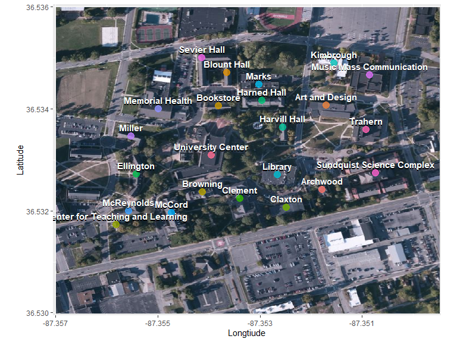

```r
campus_points <- cbind(campus.kml@data,campus.kml@coords)
campus_points[2] <- NULL
campus_points[4] <- NULL
colnames(campus_points) <- c("name","x","y")

CampusMap <- openmap(c(36.5360,-87.3570),c(36.5300,-87.3495), type='bing')
APSU <- openproj(CampusMap, projection = "+proj=longlat +ellps=WGS84 +units=m +no_defs")

autoplot(APSU) +
  geom_point(data=campus_points, aes(x = x, y = y, color = name), size = 4, alpha = 0.8) +
  geom_text(data=campus_points,aes(x = x, y = y, label = name), color="black", vjust=-0.60, size=4.01, fontface="bold") +
  geom_text(data=campus_points,aes(x = x, y = y, label = name), color="white", vjust=-0.75, fontface="bold") +
  labs(x="Longtiude", y="Latitude") + theme(legend.position = "none")
```

> Try it yourself! Link to the Main_Campus.kml file in that same folder and add a polygon of the main APSU campus to your example map above.

The only caveat to this method of adding data is the unknown longevity of the data source. Depening on the activity level of the website or repository, a simple change in storage structure could break the link location and necessitating a rewrite of your script to update to the new location.

## 2.2 Connecting to Data Distribution Networks

Sites such as **GBIF** or **Dryad** aggregate data from scientists, governments, private organizations, etc. and distribute them on open-access services. These data are likely more stable and that GitHub Repository and have consistent standards that apply to all datasets. This provides straight-forward access to a much larger catalog of data and better reproducibility.

### 2.2.1 DISMO

To start, we are going to use the `dismo` package to gain access to a simple **GBIF** dataset. Although this is slightly more complicated than linking to a ready-made dataset, sites like **GBIF** provide access to well over a million reviewed species.

The first step in obtaining data is setting the extent of the bounding box for your search. While you can access global datasets, there are limits on the amount of information you can download a limitations on your local processing power that make doing so difficult. With the extent set, you provide the genus and species along with the following basic arguments:

- geo: logical. If TRUE, only records that have a georeference (longitude and latitude values) will be downloaded
- sp: logical. If TRUE, geo will be set to TRUE and a SpatialPointsDataFrame will be returned
- removeZeros: logical. If TRUE, all records that have a latitude OR longitude of zero will be removed if geo==TRUE, or set to NA if geo==FALSE. If FALSE, only records that have a latitude AND longitude that are zero will be removed or set to NA
- download: logical. If TRUE, records will be downloaded, else only the number of records will be shown

For this example we are going to obtain records for *Pinus longaeva* within the western United States.

```r
extent <- extent(-130,-70,20,60)

pilo_dismo <- gbif("pinus", species = "longaeva", ext = extent,
             geo = TRUE, sp = TRUE, download = TRUE,
             removeZeros = TRUE)
```

Once you have obtained the 440 observations, the next step is to prepare it for display. To do this, we are going to create an x,y dataset, obtain a base map of the US, and create our map of known PILO stands in the west.

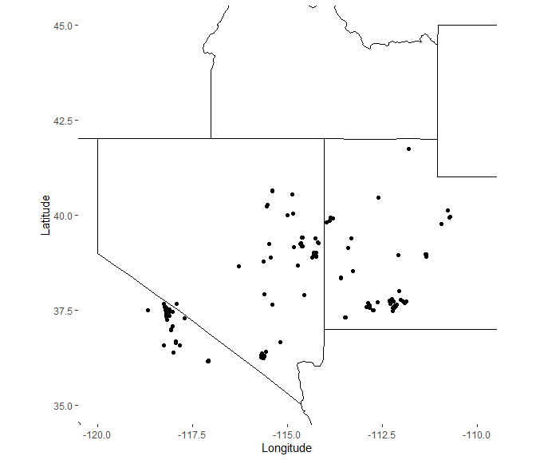

```r
pilo_xy <- as.data.frame(cbind(pilo_dismo@coords[,1],pilo_dismo@coords[,2]))
colnames(pilo_xy) <- c("longitude","latitude")

us <- map_data("state")

ggplot(data = pilo_xy, aes(x=longitude, y=latitude)) +
  geom_polygon(data = us, aes(x=long, y = lat, group = group),
               fill = "white", color="black") +
  geom_point() + xlab("Longitude") + ylab("Latitude") +
  coord_fixed(xlim = c(-120,-110), ylim = c(35,45))
```

> Give it a shot! Change the species and extent information above to create a quick custom map of a species in your thesis or research project.

This is a simple example of using the *GBIF* options in `dismo` to create a quick map of species locations. If you want a more extensive data search with additional variables we can use the `rgbif` package.

### 2.2.2 RGBIF

While the `dismo` package allowed us to create a quick species map, there were very few variables obtained with the data. Using `rgbif` will provide a more detailed look at the species.

For this part we will continue to look at Bristlecone Pine so we can evaluate the differences in the type of data. To begin with we will use the `name_lookup` function to see the available data for PILO on **GBIF**.

```r
pilo_lu <- name_lookup(query = 'pinus longaeva', return = 'data')
```

In this instance we now have 39 different variables for PILO instead of the simple geographic data collected above. In order to collect this data we will need to locate the *taxon* code, limit the records to only US collections, and then format the **gbif** data for ease of use with `ggplot2`.

```r
pilo_taxon <- print(as.integer(names(which.max(table(pilo_lu$nubKey)))))
```

```
[1] 5285258
```

```r
occ_count(taxonKey = pilo_taxon, georeferenced = TRUE)
```

```
[1] 443
```

```r
usa <- isocodes[grep("United States", isocodes$name), "code"]
pilo_data <- occ_search(taxonKey = pilo_taxon,
                   return = 'data',
                   country = usa,
                   hasCoordinate = TRUE)

pilo_df <- as.data.frame(cbind(pilo_data$US$scientificName,
                               pilo_data$US$institutionCode,
                               pilo_data$US$stateProvince,
                               pilo_data$US$verbatimLocality))

coords <- cbind(type.convert(pilo_data[["US"]][["decimalLongitude"]], as.is = TRUE),
                type.convert(pilo_data[["US"]][["decimalLatitude"]], as.is = TRUE))

pilo_info <- cbind(pilo_df,coords)

colnames(pilo_info) <- c("species","dataset","state","location","longitude","latitude")
```

Now we are ready to finalize the aesthetics and options for displaying the new **gbif** data.

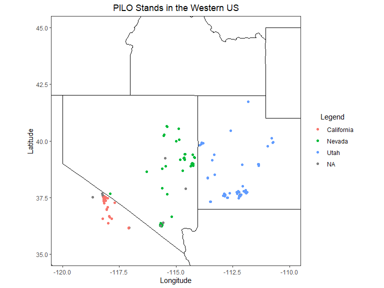

```r
ggplot(data = pilo_info, aes(x=longitude, y=latitude)) +
  geom_polygon(data = us, aes(x=long, y = lat, group = group),
               fill = "white", color="black") +
  geom_point(aes(color = state)) +
  coord_fixed(xlim = c(-120,-110), ylim = c(35,45)) +
  xlab("Longitude") + ylab("Latitude") + ggtitle("PILO Stands in the Western US") +
  guides(color=guide_legend("Legend")) +
  theme_bw() + theme(plot.title = element_text(hjust = 0.5)) +
  theme(legend.position = "right") +
  theme(legend.title.align = 0.5, legend.box.just = "center") +
  theme(panel.grid.major = element_blank(),
        panel.grid.minor = element_blank())
```

We can also use this data in `leaflet` to make an interactive version.

```r
leaflet(pilo_info) %>%
  addTiles() %>%
  addCircleMarkers(pilo_info$longitude,
                   pilo_info$latitude,
                   popup = pilo_info$state,
                   weight = 2,
                   color = "grey",
                   fillColor = "green",
                   fillOpacity = 0.7)
```

[interactive chart not shown]

> What other sort of data would you add to this map? Try selecting the species you chose above and create your own `leaflet` map with useful popups.

### 2.2.3 RDRYAD

> Data for this example is being downloaded from [Duchesne L, D’Orangeville L, Ouimet R, Houle D, Kneeshaw D (2017) Extracting coherent tree-ring climatic signals across spatial scales from extensive forest inventory data. PLoS ONE 12(12): e0189444](https://datadryad.org/stash/dataset/doi:10.5061/dryad.d69k7)

Using the `rdryad` and `utils` packages, you can download data from specific **Dryad** to import into your environment. The `dryad_fetch()` command allows you to provide a link to the dataset and an output file where the data is saved. Depending on the data format (*.csv, *.xlsx, *.zip) you will need to use another package to bring the data into your project. For this example, the authors provided data the *.xlsx in a *.zip file so we will use the `utils` package to unzip the file and `readxl` to import the dataset.

```r
nfi_data <- dryad_fetch('https://datadryad.org/stash/downloads/file_stream/76531', destfile = "./Data/nfi.zip")
unzip("Data/nfi.zip", exdir = "./Data")
reference_chrons <- read_excel("Data/RererenceChronologies.xlsx",
                               col_types = c("text", "skip", "skip",
                                             "numeric", "numeric"))
```

The script above created the specific columns we needed from the dataset to continue the analysis. If you are unsure which columns in a given file you may need, the interactive button allows you to view the data and provides the script along with the GUI interface for importing information.

Because this specific dataset contained a number of duplication location entries due to the data format, we can use the `unique()` command to subset only the locations of each study site and create a location map.

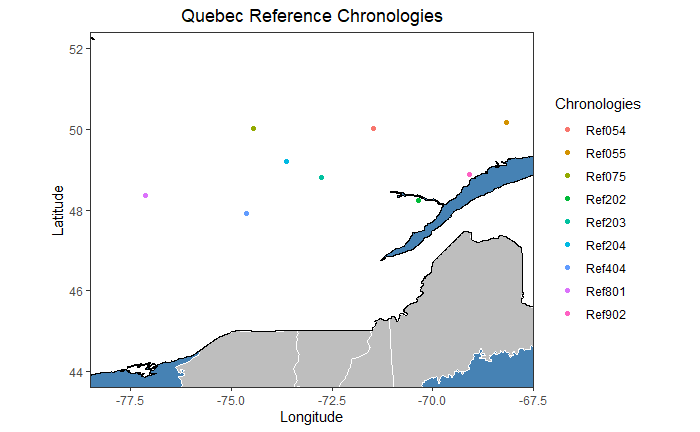

```r
canada <- map_data("worldHires", "Canada")

ggplot(chronologies, aes(Longitude, Latitude)) +
  geom_polygon(data = us, aes(x=long, y = lat, group = group),
               fill = "gray", color="white") +
  geom_polygon(data = canada, aes(x=long, y = lat, group = group),
               fill = "white", color="black") +
  geom_point(aes(color = chronologies$ChronID)) +
  coord_fixed(xlim = c(-78,-68), ylim = c(44,52)) +
  xlab("Longitude") + ylab("Latitude") + ggtitle("Quebec Reference Chronologies") +
  guides(color=guide_legend("Chronologies")) +
  theme_bw() + theme(plot.title = element_text(hjust = 0.5)) +
  theme(legend.position = "right") +
  theme(legend.title.align = 0.5, legend.box.just = "center") +
  theme(panel.grid.major = element_blank(),
        panel.grid.minor = element_blank(),
        panel.background = element_rect(fill = "steelblue"))
```

## 2.3 Application Programming Interface or APIs

Occasionally you may be required to include potentially sensitive information in a script in order to access data or a programs API. In this instance, rather than including that information in your `markdown` document, you can include these as an environment variable. While RStudio has the ability to read files that begin with a . such as a .gitignore file, typical file browsers will ignore these unless specifically told to view all hidden files. So as we have done before, we can use `touch .Renviron` in **BASH** or `nul > .Renviron` in the **Terminal** to create and environment file. This file can be added to your .gitignore information so the API key remains on your local computer accessible to your project but will not be pushed to your repository and be available to anyone.

In the .Renviron file, include the specific information required by the package formatted, provide a line break or extra line below the last line of commands, and save the file to the root directory of your project. In order to proceed, you must restart your session so the environment file is processed at the start of your new session. Now you simply need to refer to that data when using that particular package. For example, I have a .Renviron file included in this exercise that contains an *API* and *ID* for **Spotify**. In order to gain access to data for this exercise I need to request access using this information in the `spotifyr` package.

```r
Sys.setenv(SPOTIFY_CLIENT_ID = Sys.getenv('SPOTIFY_CLIENT_ID'))
Sys.setenv(SPOTIFY_CLIENT_SECRET = Sys.getenv('SPOTIFY_CLIENT_SECRET'))

spotify_token <- get_spotify_access_token()
```

This information allows me to gain access to the **Spotify** data but only shows the title links to the information contained in the .Renviron file. Using this access we can connect to data stored on the **Spotify** servers regarding information for specific artists.

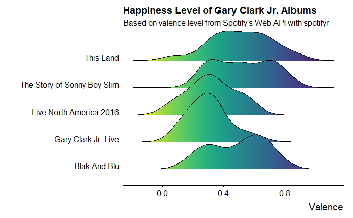

```r
GCJ <- get_artist_audio_features('Gary Clark Jr.')

ggplot(GCJ, aes(x = valence, y = album_name, fill = ..x..)) +
  geom_density_ridges_gradient(gradient_lwd = 0, alpha=0.5) +
  theme_ridges(grid=FALSE) +
  scale_fill_viridis(option = "D", direction = -1) +
  labs(title = "Happiness Level of Gary Clark Jr. Albums",
       subtitle = paste0("Based on valence level from Spotify's Web API with spotifyr"),
       x = "Valence", y = "") +
  theme(legend.position = "none") + theme(axis.line.x = element_line(color="black"))
```

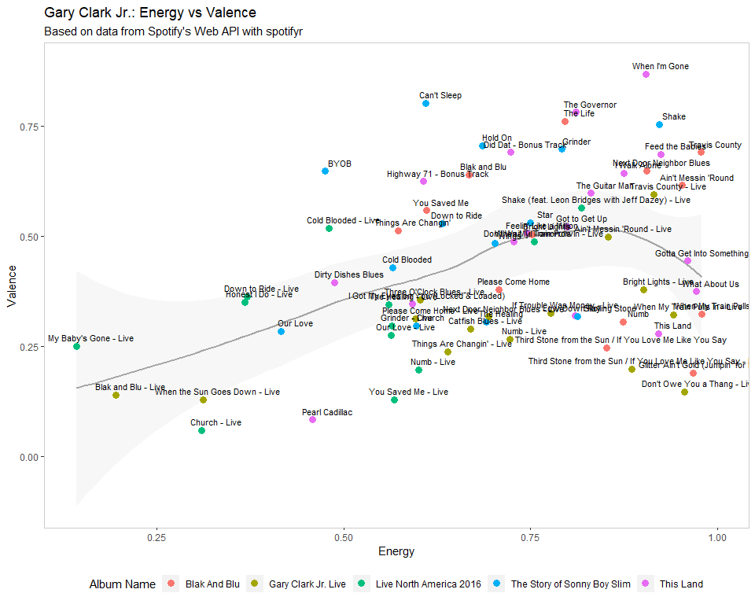

```r
GCJ_info <- GCJ %>% select(album_name, track_name, energy, valence, tempo)

ggplot(GCJ_info) +
  geom_smooth(aes(x = energy, y = valence),
              method = "loess", color = "gray65", fill = "gray85", alpha = 0.2) +
  geom_point(aes(x = energy, y = valence, color = album_name), size = 3) +
  geom_text(aes(x = energy, y = valence, label = track_name),
            hjust = 'above', size = 3, nudge_y = .02, nudge_x = .02) +
  labs(title = "Gary Clark Jr.: Energy vs Valence",
       subtitle = paste0("Based on data from Spotify's Web API with spotifyr"),
       x = "Energy", y = "Valence") +
  theme(legend.position = "bottom") +
  guides(color=guide_legend("Album Name")) +
  theme(panel.background = element_rect(fill = "white")) +
  theme(panel.border = element_rect(color="gray80", fill = FALSE))
```

# 3 Simple Species Distribution Map

Finally, using a number of the packages included above, we can examine factors that might influence the location of a particular species. For this example we will return to the PILO data and use bioclimatic variables from worldclim.org to examine the relationship between climate variables and PILO stands in the western US.

```r
bioclim <- getData(name = "worldclim", res = 2.5, var = "bio", path = "./Data")

names(bioclim) <- c("Ann Mean Temp","Mean Diurnal Range","Isothermality","Temperature Seasonality",
                           "Max Temp Warmest Mo","Min Temp Coldest Mo","Ann Temp Range","Mean Temp Wettest Qtr",
                           "Mean Temp Driest Qtr","Mean Temp Warmest Qtr","Mean Temp Coldest Qtr","Annual Precip",
                           "Precip Wettest Mo","Precip Driest Mo","Precip Seasonality","Precip Wettest Qtr",
                           "Precip Driest Qtr","Precip Warmest Qtr","Precip Coldest Qtr")

bio_extent <- extent(x = c(
  min(pilo_xy$longitude),
  max(pilo_xy$longitude),
  min(pilo_xy$latitude),
  max(pilo_xy$latitude)))

bioclim_extent <- crop(x = bioclim, y = bio_extent)
bioclim_model <- bioclim(x = bioclim_extent, p = pilo_xy)
presence_model <- dismo::predict(object = bioclim_model,
                                 x = bioclim_extent,
                                 ext = bio_extent)
```

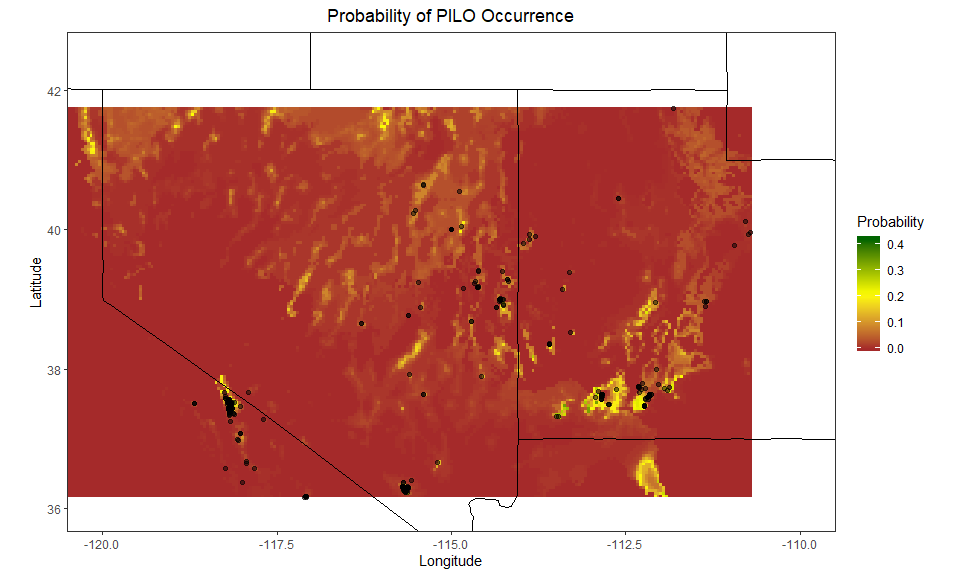

```r
gplot(presence_model) +
  geom_raster(aes(fill=value)) +
  geom_polygon(data = us, aes(x= long, y = lat, group = group),
               fill = NA, color="black") +
  geom_point(data = pilo_xy, aes(x = longitude, y = latitude), color = "black", alpha = 0.5) +
  scale_fill_gradientn(colours=c("brown","yellow","darkgreen"), "Probability") +
  coord_fixed(xlim = c(-120,-110), ylim = c(36,42.5)) +
  xlab("Longitude") + ylab("Latitude") + ggtitle("Probability of PILO Occurrence") +
  theme_bw() + theme(plot.title = element_text(hjust = 0.5)) + theme(legend.position = "right") +
  theme(panel.grid.major = element_blank(),
        panel.grid.minor = element_blank())
```

You can also view this information in `leaflet` to examine the data interactively.

```r
colors <- c("brown","yellow","darkgreen")

leaflet() %>%
  addTiles() %>%
  addRasterImage(presence_model, colors = colors, opacity = 0.8) %>%
  addCircleMarkers(pilo_xy$longitude,
                   pilo_xy$latitude,
                   weight = 1,
                   color = "grey",
                   fillColor = "green",
                   fillOpacity = 0.7)
```

[interactive chart not shown]

# 4 YOUR TURN!

Now it’s your turn! Although some of this might not be applicable to your thesis research, try this information out on a dataset of your choice from any of the sources above. If you can apply this to your thesis, then add it to your website! Otherwise create a new repository for your work on Thursday.